> **Tip**: Welcome to the Investigate a Dataset project! You will find tips in quoted sections like this to help organize your approach to your investigation. Before submitting your project, it will be a good idea to go back through your report and remove these sections to make the presentation of your work as tidy as possible. First things first, you might want to double-click this Markdown cell and change the title so that it reflects your dataset and investigation.

# Project: Hospitals in Brazil No-show Data Analysis

- Introduction
- Data Wrangling
- Exploratory Data Analysis
- Conclusions

## Introduction

> **Tip**: In this section of the report, provide a brief introduction to the dataset you've selected for analysis. At the end of this section, describe the questions that you plan on exploring over the course of the report. Try to build your report around the analysis of at least one dependent variable and three independent variables. If you're not sure what questions to ask, then make sure you familiarize yourself with the dataset, its variables and the dataset context for ideas of what to explore.

> If you haven't yet selected and downloaded your data, make sure you do that first before coming back here. In order to work with the data in this workspace, you also need to upload it to the workspace. To do so, click on the jupyter icon in the upper left to be taken back to the workspace directory. There should be an 'Upload' button in the upper right that will let you add your data file(s) to the workspace. You can then click on the .ipynb file name to come back here.

```python
#import csv file
import numpy as np
import pandas as pd
import matplotlib.pyplot as plt
import seaborn as sns
%matplotlib inline
```

## Data Wrangling

> **Tip**: In this section of the report, you will load in the data, check for cleanliness, and then trim and clean your dataset for analysis. Make sure that you document your steps carefully and justify your cleaning decisions.

### General Properties

```python
df = pd.read_csv('noshowappointments-kagglev2-may-2016.csv')
df.head()
```

|  | PatientId | AppointmentID | Gender | ScheduledDay | AppointmentDay | Age | Neighbourhood | Scholarship | Hipertension | Diabetes | Alcoholism | Handcap | SMS_received | No-show |
| --- | --- | --- | --- | --- | --- | --- | --- | --- | --- | --- | --- | --- | --- | --- |
| 0 | 2.987250e+13 | 5642903 | F | 2016-04-29T18:38:08Z | 2016-04-29T00:00:00Z | 62 | JARDIM DA PENHA | 0 | 1 | 0 | 0 | 0 | 0 | No |
| 1 | 5.589978e+14 | 5642503 | M | 2016-04-29T16:08:27Z | 2016-04-29T00:00:00Z | 56 | JARDIM DA PENHA | 0 | 0 | 0 | 0 | 0 | 0 | No |
| 2 | 4.262962e+12 | 5642549 | F | 2016-04-29T16:19:04Z | 2016-04-29T00:00:00Z | 62 | MATA DA PRAIA | 0 | 0 | 0 | 0 | 0 | 0 | No |
| 3 | 8.679512e+11 | 5642828 | F | 2016-04-29T17:29:31Z | 2016-04-29T00:00:00Z | 8 | PONTAL DE CAMBURI | 0 | 0 | 0 | 0 | 0 | 0 | No |
| 4 | 8.841186e+12 | 5642494 | F | 2016-04-29T16:07:23Z | 2016-04-29T00:00:00Z | 56 | JARDIM DA PENHA | 0 | 1 | 1 | 0 | 0 | 0 | No |

```python
df.shape
```

```
(110527, 14)
```

```python
df.describe()
```

|  | PatientId | AppointmentID | Age | Scholarship | Hipertension | Diabetes | Alcoholism | Handcap | SMS_received |
| --- | --- | --- | --- | --- | --- | --- | --- | --- | --- |
| count | 1.105270e+05 | 1.105270e+05 | 110527.000000 | 110527.000000 | 110527.000000 | 110527.000000 | 110527.000000 | 110527.000000 | 110527.000000 |
| mean | 1.474963e+14 | 5.675305e+06 | 37.088874 | 0.098266 | 0.197246 | 0.071865 | 0.030400 | 0.022248 | 0.321026 |
| std | 2.560949e+14 | 7.129575e+04 | 23.110205 | 0.297675 | 0.397921 | 0.258265 | 0.171686 | 0.161543 | 0.466873 |
| min | 3.921784e+04 | 5.030230e+06 | -1.000000 | 0.000000 | 0.000000 | 0.000000 | 0.000000 | 0.000000 | 0.000000 |
| 25% | 4.172614e+12 | 5.640286e+06 | 18.000000 | 0.000000 | 0.000000 | 0.000000 | 0.000000 | 0.000000 | 0.000000 |
| 50% | 3.173184e+13 | 5.680573e+06 | 37.000000 | 0.000000 | 0.000000 | 0.000000 | 0.000000 | 0.000000 | 0.000000 |
| 75% | 9.439172e+13 | 5.725524e+06 | 55.000000 | 0.000000 | 0.000000 | 0.000000 | 0.000000 | 0.000000 | 1.000000 |
| max | 9.999816e+14 | 5.790484e+06 | 115.000000 | 1.000000 | 1.000000 | 1.000000 | 1.000000 | 4.000000 | 1.000000 |

```python
df.drop(['PatientId', 'AppointmentID'], axis = 1, inplace = True)
```

```python
df.head()
```

|  | Gender | ScheduledDay | AppointmentDay | Age | Neighbourhood | Scholarship | Hipertension | Diabetes | Alcoholism | Handcap | SMS_received | No-show |
| --- | --- | --- | --- | --- | --- | --- | --- | --- | --- | --- | --- | --- |
| 0 | F | 2016-04-29T18:38:08Z | 2016-04-29T00:00:00Z | 62 | JARDIM DA PENHA | 0 | 1 | 0 | 0 | 0 | 0 | No |
| 1 | M | 2016-04-29T16:08:27Z | 2016-04-29T00:00:00Z | 56 | JARDIM DA PENHA | 0 | 0 | 0 | 0 | 0 | 0 | No |
| 2 | F | 2016-04-29T16:19:04Z | 2016-04-29T00:00:00Z | 62 | MATA DA PRAIA | 0 | 0 | 0 | 0 | 0 | 0 | No |
| 3 | F | 2016-04-29T17:29:31Z | 2016-04-29T00:00:00Z | 8 | PONTAL DE CAMBURI | 0 | 0 | 0 | 0 | 0 | 0 | No |
| 4 | F | 2016-04-29T16:07:23Z | 2016-04-29T00:00:00Z | 56 | JARDIM DA PENHA | 0 | 1 | 1 | 0 | 0 | 0 | No |

```python
df.info()
```

```
<class 'pandas.core.frame.DataFrame'>
RangeIndex: 110527 entries, 0 to 110526
Data columns (total 12 columns):
Gender            110527 non-null object
ScheduledDay      110527 non-null object
AppointmentDay    110527 non-null object
Age               110527 non-null int64
Neighbourhood     110527 non-null object
Scholarship       110527 non-null int64
Hipertension      110527 non-null int64
Diabetes          110527 non-null int64
Alcoholism        110527 non-null int64
Handcap           110527 non-null int64
SMS_received      110527 non-null int64
No-show           110527 non-null object
dtypes: int64(7), object(5)
memory usage: 10.1+ MB
```

> **Tip**: You should *not* perform too many operations in each cell. Create cells freely to explore your data. One option that you can take with this project is to do a lot of explorations in an initial notebook. These don't have to be organized, but make sure you use enough comments to understand the purpose of each code cell. Then, after you're done with your analysis, create a duplicate notebook where you will trim the excess and organize your steps so that you have a flowing, cohesive report.

> **Tip**: Make sure that you keep your reader informed on the steps that you are taking in your investigation. Follow every code cell, or every set of related code cells, with a markdown cell to describe to the reader what was found in the preceding cell(s). Try to make it so that the reader can then understand what they will be seeing in the following cell(s).

### Data Cleaning : Filter only No-show values

```python
df.rename(index = str, columns ={'No-show': "No_show"}, inplace = True)
df.head()
```

|  | Gender | ScheduledDay | AppointmentDay | Age | Neighbourhood | Scholarship | Hipertension | Diabetes | Alcoholism | Handcap | SMS_received | No_show |
| --- | --- | --- | --- | --- | --- | --- | --- | --- | --- | --- | --- | --- |
| 0 | F | 2016-04-29T18:38:08Z | 2016-04-29T00:00:00Z | 62 | JARDIM DA PENHA | 0 | 1 | 0 | 0 | 0 | 0 | No |
| 1 | M | 2016-04-29T16:08:27Z | 2016-04-29T00:00:00Z | 56 | JARDIM DA PENHA | 0 | 0 | 0 | 0 | 0 | 0 | No |
| 2 | F | 2016-04-29T16:19:04Z | 2016-04-29T00:00:00Z | 62 | MATA DA PRAIA | 0 | 0 | 0 | 0 | 0 | 0 | No |
| 3 | F | 2016-04-29T17:29:31Z | 2016-04-29T00:00:00Z | 8 | PONTAL DE CAMBURI | 0 | 0 | 0 | 0 | 0 | 0 | No |
| 4 | F | 2016-04-29T16:07:23Z | 2016-04-29T00:00:00Z | 56 | JARDIM DA PENHA | 0 | 1 | 1 | 0 | 0 | 0 | No |

```python
df_noshow = df[df['No_show'] == 'Yes']
df_noshow.drop(['No_show'],axis = 1, inplace =True)
```

```python
df_noshow.head()
```

|  | Gender | ScheduledDay | AppointmentDay | Age | Neighbourhood | Scholarship | Hipertension | Diabetes | Alcoholism | Handcap | SMS_received |
| --- | --- | --- | --- | --- | --- | --- | --- | --- | --- | --- | --- |
| 6 | F | 2016-04-27T15:05:12Z | 2016-04-29T00:00:00Z | 23 | GOIABEIRAS | 0 | 0 | 0 | 0 | 0 | 0 |
| 7 | F | 2016-04-27T15:39:58Z | 2016-04-29T00:00:00Z | 39 | GOIABEIRAS | 0 | 0 | 0 | 0 | 0 | 0 |
| 11 | M | 2016-04-26T08:44:12Z | 2016-04-29T00:00:00Z | 29 | NOVA PALESTINA | 0 | 0 | 0 | 0 | 0 | 1 |
| 17 | F | 2016-04-28T09:28:57Z | 2016-04-29T00:00:00Z | 40 | CONQUISTA | 1 | 0 | 0 | 0 | 0 | 0 |
| 20 | F | 2016-04-27T07:51:14Z | 2016-04-29T00:00:00Z | 30 | NOVA PALESTINA | 0 | 0 | 0 | 0 | 0 | 0 |

```python
df_noshow.shape
```

```
(22319, 11)
```

```python
df_show = df[df['No_show'] == 'No']
df_show.drop(['No_show'],axis = 1, inplace =True)
df_show.shape
```

```
(88208, 11)
```

## Exploratory Data Analysis

> **Tip**: Now that you've trimmed and cleaned your data, you're ready to move on to exploration. Compute statistics and create visualizations with the goal of addressing the research questions that you posed in the Introduction section. It is recommended that you be systematic with your approach. Look at one variable at a time, and then follow it up by looking at relationships between variables.

### Research Question 1 : What is the most factor impacted on No-show rates?

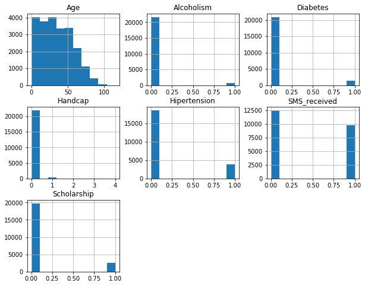

```python
df_noshow.hist(figsize =( 10,8));
```

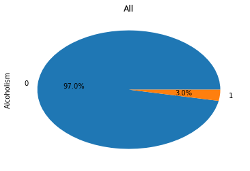

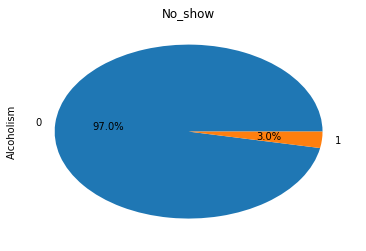

```python
plt.figure(0)
df['Alcoholism'].value_counts().plot(kind='pie', title = 'All', autopct = '%1.1f%%');
plt.figure(1)
df_noshow['Alcoholism'].value_counts().plot(kind='pie', title = 'No_show',autopct = '%1.1f%%');
```

> Alcholism does not have any relationship with No-show.

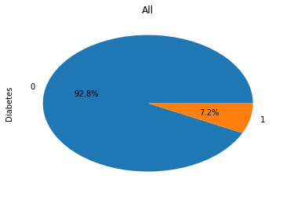

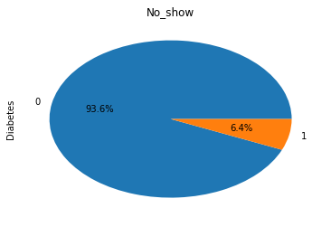

```python
plt.figure(0)
df['Diabetes'].value_counts().plot(kind='pie', title = 'All', autopct = '%1.1f%%');
plt.figure(1)
df_noshow['Diabetes'].value_counts().plot(kind='pie', title = 'No_show', autopct = '%1.1f%%');
```

> If the patient has Diabetes, he/she tends to No-show less.(0.8% decrease)

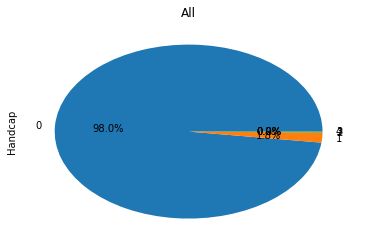

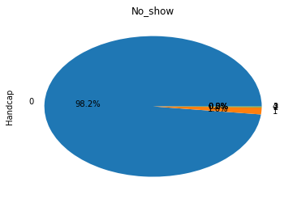

```python
plt.figure(0)
df['Handcap'].value_counts().plot(kind='pie',title = 'All', autopct = '%1.1f%%');
plt.figure(1)
df_noshow['Handcap'].value_counts().plot(kind='pie', title = 'No_show',autopct = '%1.1f%%');
```

```python
df_noshow['Handcap'].value_counts()
```

```
0    21912
1      366
2       37
3        3
4        1
Name: Handcap, dtype: int64
```

> The normal patient has slightly more tendency of No-show.

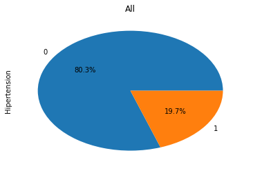

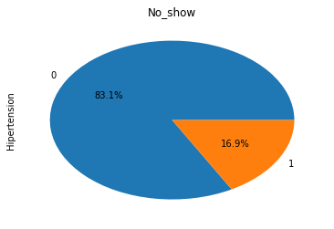

```python
plt.figure(0)
df['Hipertension'].value_counts().plot(kind='pie',title = 'All', autopct = '%1.1f%%');
plt.figure(1)
df_noshow['Hipertension'].value_counts().plot(kind='pie',title = 'No_show', autopct = '%1.1f%%');
```

> The patient with Hipertension has lower tendency of No-show.(2.8% decrease)

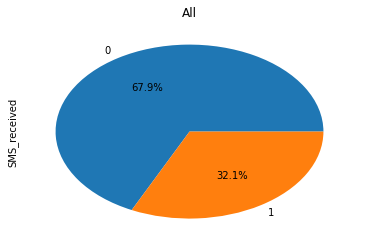

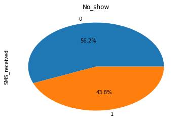

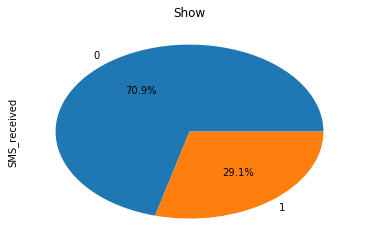

```python
plt.figure(0)
df['SMS_received'].value_counts().plot(kind='pie',title = 'All', autopct = '%1.1f%%');
plt.figure(1)
df_noshow['SMS_received'].value_counts().plot(kind='pie', title = 'No_show',autopct = '%1.1f%%');
plt.figure(2)
df_show['SMS_received'].value_counts().plot(kind='pie', title ='Show', autopct= '%1.1f%%');
```

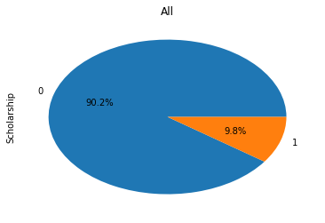

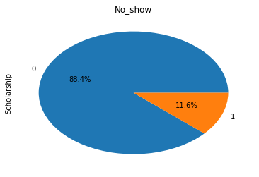

```python
plt.figure(0)
df['Scholarship'].value_counts().plot(kind='pie',title = 'All', autopct = '%1.1f%%');
plt.figure(1)
df_noshow['Scholarship'].value_counts().plot(kind='pie', title = 'No_show',autopct = '%1.1f%%');
```

> The patient with Scholarship tends to more absence.(1.8% increase)

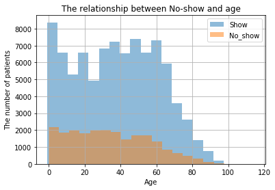

```python
df_show.Age.hist(alpha=0.5, bins=20, label='Show');
df_noshow.Age.hist(alpha=0.5, bins=20, label='No_show');
plt.title('The relationship between No-show and age')
plt.xlabel('Age')
plt.ylabel('The number of patients')
plt.legend();
```

> Middle teenager and early 20s tend to have higher No-show rates.

### Research Question 2 : Does the location of hospital have the relationship with No-show rates?

```python
ds_no_nbh = df_noshow['Neighbourhood'].value_counts()
df_no_nbh = pd.DataFrame(ds_no_nbh)
df_no_nbh.reset_index(level=0, inplace =True)
df_no_nbh.rename(columns={"Neighbourhood":"Count"}, inplace = True)
df_no_nbh.rename(columns={"index":"Neighbourhood"}, inplace = True)
df_no_nbh.head()
```

|  | Neighbourhood | Count |
| --- | --- | --- |
| 0 | JARDIM CAMBURI | 1465 |
| 1 | MARIA ORTIZ | 1219 |
| 2 | ITARARÉ | 923 |
| 3 | RESISTÊNCIA | 906 |
| 4 | CENTRO | 703 |

```python
ds_all_nbh = df['Neighbourhood'].value_counts()
df_all_nbh = pd.DataFrame(ds_all_nbh)
df_all_nbh.reset_index(level=0, inplace =True)
df_all_nbh.rename(columns={"Neighbourhood":"Count"}, inplace = True)
df_all_nbh.rename(columns={"index":"Neighbourhood"}, inplace = True)
df_all_nbh.head()
```

|  | Neighbourhood | Count |
| --- | --- | --- |
| 0 | JARDIM CAMBURI | 7717 |
| 1 | MARIA ORTIZ | 5805 |
| 2 | RESISTÊNCIA | 4431 |
| 3 | JARDIM DA PENHA | 3877 |
| 4 | ITARARÉ | 3514 |

```python
ds_nbh = ds_no_nbh/ds_all_nbh
df_nbh = pd.DataFrame(ds_nbh)
df_nbh.reset_index(level=0, inplace =True)
df_nbh.rename(columns={"Neighbourhood":"Percent"}, inplace = True)
df_nbh.rename(columns={"index":"Neighbourhood"}, inplace = True)
df_nbh.sort_values(['Percent'], ascending = False)
```

|  | Neighbourhood | Percent |
| --- | --- | --- |
| 34 | ILHAS OCEÂNICAS DE TRINDADE | 1.000000 |
| 70 | SANTOS DUMONT | 0.289185 |
| 61 | SANTA CECÍLIA | 0.274554 |
| 62 | SANTA CLARA | 0.264822 |
| 36 | ITARARÉ | 0.262664 |
| 40 | JESUS DE NAZARETH | 0.243954 |
| 28 | HORTO | 0.240000 |
| 33 | ILHA DO PRÍNCIPE | 0.234775 |
| 9 | CARATOÍRA | 0.230409 |
| 1 | ANDORINHAS | 0.230327 |
| 56 | PRAIA DO SUÁ | 0.228261 |
| 27 | GURIGICA | 0.225966 |
| 6 | BENTO FERREIRA | 0.224942 |
| 52 | PARQUE MOSCOSO | 0.223192 |
| 44 | MARUÍPE | 0.222923 |
| 18 | DO MOSCOSO | 0.222760 |
| 20 | ENSEADA DO SUÁ | 0.221277 |
| 3 | ARIOVALDO FAVALESSA | 0.219858 |
| 29 | ILHA DAS CAIEIRAS | 0.219421 |
| 22 | FONTE GRANDE | 0.218475 |
| 14 | CRUZAMENTO | 0.217454 |
| 76 | SÃO JOSÉ | 0.216490 |
| 4 | BARRO VERMELHO | 0.215130 |
| 49 | NAZARETH | 0.214815 |
| 60 | ROMÃO | 0.213995 |
| 10 | CENTRO | 0.210858 |
| 79 | UNIVERSITÁRIO | 0.210526 |
| 77 | SÃO PEDRO | 0.210376 |
| 43 | MARIA ORTIZ | 0.209991 |
| 63 | SANTA HELENA | 0.207865 |
| ... | ... | ... |
| 12 | CONQUISTA | 0.188457 |
| 24 | FRADINHOS | 0.186047 |
| 7 | BOA VISTA | 0.185897 |
| 2 | ANTÔNIO HONÓRIO | 0.184502 |
| 55 | PRAIA DO CANTO | 0.183575 |
| 23 | FORTE SÃO JOÃO | 0.183166 |
| 78 | TABUAZEIRO | 0.182950 |
| 41 | JOANA D´ARC | 0.180799 |
| 11 | COMDUSA | 0.180645 |
| 64 | SANTA LUÍZA | 0.179907 |
| 37 | JABOUR | 0.179753 |
| 50 | NOVA PALESTINA | 0.177562 |
| 57 | REDENÇÃO | 0.177077 |
| 69 | SANTO ANTÔNIO | 0.176256 |
| 54 | PONTAL DE CAMBURI | 0.173913 |
| 13 | CONSOLAÇÃO | 0.172238 |
| 58 | REPÚBLICA | 0.171257 |
| 45 | MATA DA PRAIA | 0.170807 |
| 47 | MORADA DE CAMBURI | 0.166667 |
| 80 | VILA RUBIM | 0.165687 |
| 19 | DO QUADRO | 0.164900 |
| 39 | JARDIM DA PENHA | 0.162755 |
| 66 | SANTA MARTHA | 0.158416 |
| 17 | DO CABRAL | 0.157143 |
| 16 | DE LOURDES | 0.154098 |
| 73 | SOLON BORGES | 0.147122 |
| 48 | MÁRIO CYPRESTE | 0.145553 |
| 0 | AEROPORTO | 0.125000 |
| 31 | ILHA DO BOI | 0.085714 |
| 51 | PARQUE INDUSTRIAL | NaN |

81 rows × 2 columns

```python
df_nbh.describe()
```

|  | Percent |
| --- | --- |
| count | 80.000000 |
| mean | 0.207995 |
| std | 0.095039 |
| min | 0.085714 |
| 25% | 0.180461 |
| 50% | 0.197650 |
| 75% | 0.217709 |
| max | 1.000000 |

```python
df.query('Neighbourhood =="ILHAS OCEÂNICAS DE TRINDADE"')
```

|  | Gender | ScheduledDay | AppointmentDay | Age | Neighbourhood | Scholarship | Hipertension | Diabetes | Alcoholism | Handcap | SMS_received | No_show |
| --- | --- | --- | --- | --- | --- | --- | --- | --- | --- | --- | --- | --- |
| 48754 | F | 2016-04-14T12:25:43Z | 2016-05-13T00:00:00Z | 51 | ILHAS OCEÂNICAS DE TRINDADE | 0 | 0 | 0 | 0 | 0 | 0 | Yes |
| 48765 | F | 2016-04-14T12:26:13Z | 2016-05-13T00:00:00Z | 58 | ILHAS OCEÂNICAS DE TRINDADE | 0 | 0 | 0 | 0 | 0 | 0 | Yes |

```python
df_nbh.query('Neighbourhood == "JARDIM CAMBURI"')
```

|  | Neighbourhood | Percent |
| --- | --- | --- |
| 38 | JARDIM CAMBURI | 0.189841 |

```python
df.query('Neighbourhood =="SANTOS DUMONT"').count()
```

```
Gender            1276
ScheduledDay      1276
AppointmentDay    1276
Age               1276
Neighbourhood     1276
Scholarship       1276
Hipertension      1276
Diabetes          1276
Alcoholism        1276
Handcap           1276
SMS_received      1276
No_show           1276
dtype: int64
```

> The patients who live in ILHAS OCEÂNICAS DE TRINDADE are only two. It can be ingnored. Although Jardim Camburi seems a lot of no-show patients, its rate comparing to the all is lower than average rate so it is not significant. On the other hand, SANTOS DUMONT has higher rate of no-show.

## Conclusions

> **Tip**: Finally, summarize your findings and the results that have been performed. Make sure that you are clear with regards to the limitations of your exploration. If you haven't done any statistical tests, do not imply any statistical conclusions. And make sure you avoid implying causation from correlation!

> **Tip**: Once you are satisfied with your work here, check over your report to make sure that it is satisfies all the areas of the rubric (found on the project submission page at the end of the lesson). You should also probably remove all of the "Tips" like this one so that the presentation is as polished as possible.

> I would like to find out which factor is the most related to increasing No-show rate in Brazil hospital through this report.

> • Case history such as hypertension, diabetes and so on is not a significant relationship with absence. Slightly the patients who have sickness have a good attendance.

> • Scholarship is not helpful to reduce No-show rate. The patient with scholarship has more absence rate.

> • Age is an import factor. Middle teenager and early 20s tend to have higher No-show rates.

> • Location is not a visible matter of No-show. The difference of no-show rates base on location is not a significant. The average is 0.207 and 25% and 75% rate do not have a big difference.

## Submitting your Project

> Before you submit your project, you need to create a .html or .pdf version of this notebook in the workspace here. To do that, run the code cell below. If it worked correctly, you should get a return code of 0, and you should see the generated .html file in the workspace directory (click on the orange Jupyter icon in the upper left).

> Alternatively, you can download this report as .html via the **File** > **Download as** submenu, and then manually upload it into the workspace directory by clicking on the orange Jupyter icon in the upper left, then using the Upload button.

> Once you've done this, you can submit your project by clicking on the "Submit Project" button in the lower right here. This will create and submit a zip file with this .ipynb doc and the .html or .pdf version you created. Congratulations!

## Reference

> https://pandas.pydata.org

> https://stackoverflow.com

> https://matplotlib.org

```python
from subprocess import call
call(['python', '-m', 'nbconvert', 'Investigate_a_Dataset.ipynb'])
```